# 5215 Assignment 3,4,5,6

Cam Marina Manoel

# Research Question

What is the relationship between income and 2020 presidential voting in counties that are large metropolitan areas?

# Prior Research

Verba (1995) has shown that voting participation in the United States is strongly correlated with income. Gelman et al (2010) find that wealthier people tend to vote Republican in national elections, while observing more prosperous states favor the Democratic candidate. In our experiment, we look into the correlations between socioeconomic variables and voting trends in national elections at the county level.

# Data

The sample population for this study is the full set of all counties and large metropolitan areas in the United States. The analysis will include the following variables:

- Geographic area size (NCHSUR Codes, 2013)
- Winning political party at last presidential election (MIT Election Data and Science Lab, 2018)
- Income to poverty ratio (American Community Survey, 2019)
- Household Income (American Community Survey, 2019)
- Gini Index (American Community Survey, 2019)
- Total Population (United States Census Bureau, 2020)

| NAME | type | income_to_poverty_E | household_income_E | gini_index_E | majority_vote | pop |
| --- | --- | --- | --- | --- | --- | --- |
| Black Hawk County, Iowa | Small metro | 27468 | 52905 | 0.4694 | Democrat | 102527 |
| Black Hawk County, Iowa | Small metro | 27468 | 52905 | 0.4694 | Democrat | 102527 |
| Black Hawk County, Iowa | Small metro | 27468 | 52905 | 0.4694 | Democrat | 102527 |
| Black Hawk County, Iowa | Small metro | 27468 | 52905 | 0.4694 | Democrat | 102527 |
| Black Hawk County, Iowa | Small metro | 27468 | 52905 | 0.4694 | Democrat | 102527 |
| Black Hawk County, Iowa | Small metro | 27468 | 52905 | 0.4694 | Democrat | 102527 |

## Descriptive statistics

### Continuous variables

- Income to poverty ratio (American Community Survey, 2019)
- Household Income (American Community Survey, 2019)
- Gini Index (American Community Survey, 2019)
- Total Population (United States Census Bureau, 2020)

#### Calculations & Results

```
##
##  One Sample t-test
##
## data:  data$household_income_E
## t = 52.196, df = 21991, p-value < 2.2e-16
## alternative hypothesis: true mean is not equal to 0
## 95 percent confidence interval:
##  36693.28 39556.65
## sample estimates:
## mean of x
##  38124.97
```

```
##      0%     25%     50%     75%    100%
##      30    5106   10790   29033 3316795
```

```
## [1] 108319.7
```

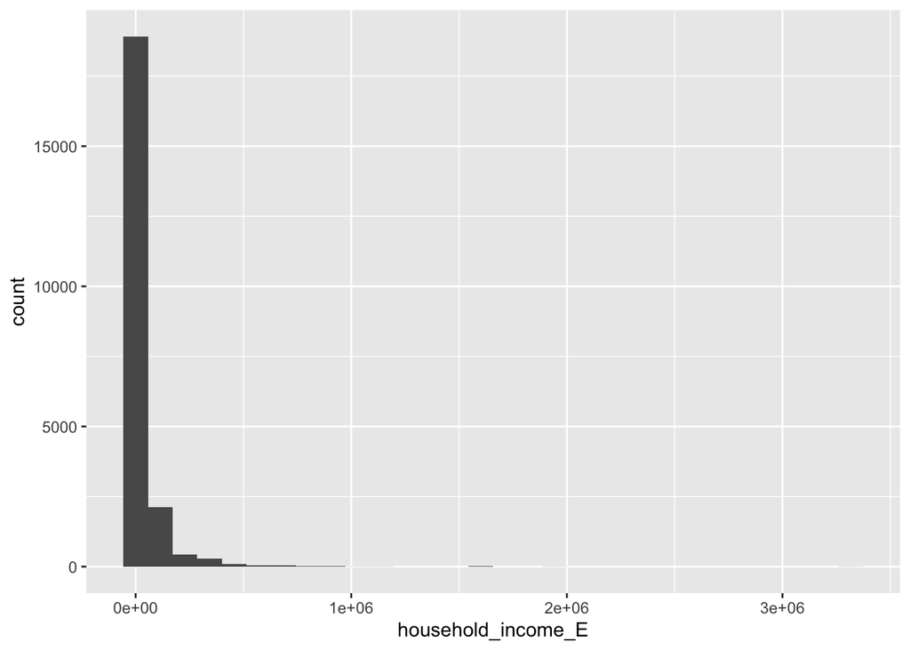

```
##
##  One Sample t-test
##
## data:  data$income_to_poverty_E
## t = 48.634, df = 21991, p-value < 2.2e-16
## alternative hypothesis: true mean is not equal to 0
## 95 percent confidence interval:
##  21291.17 23079.41
## sample estimates:
## mean of x
##  22185.29
```

```
##      0%     25%     50%     75%    100%
##       0    2589    5748   15580 2113147
```

```
## [1] 67648.21
```

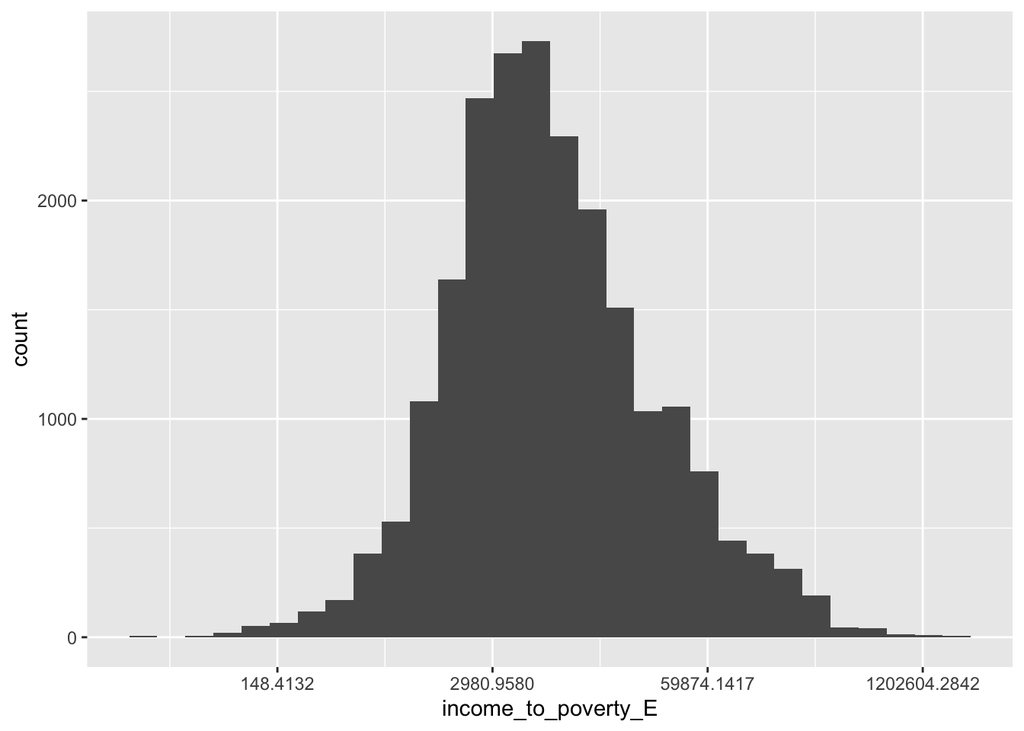

```
##
##  One Sample t-test
##
## data:  data$gini_index_E
## t = 1825.3, df = 21991, p-value < 2.2e-16
## alternative hypothesis: true mean is not equal to 0
## 95 percent confidence interval:
##  0.4476113 0.4485737
## sample estimates:
## mean of x
## 0.4480925
```

```
##     0%    25%    50%    75%   100%
## 0.3023 0.4233 0.4467 0.4702 0.7070
```

```
## [1] 0.03640557
```

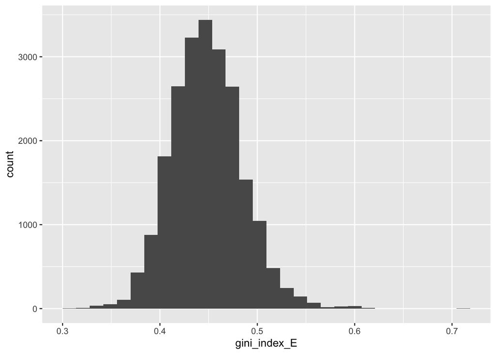

```
##
##  One Sample t-test
##
## data:  data$pop
## t = 49.75, df = 21993, p-value < 2.2e-16
## alternative hypothesis: true mean is not equal to 0
## 95 percent confidence interval:
##  78279.27 84700.48
## sample estimates:
## mean of x
##  81489.87
```

```
##      0%     25%     50%     75%    100%
##      40   10114   22052   60393 7959791
```

```
## [1] 242922
```

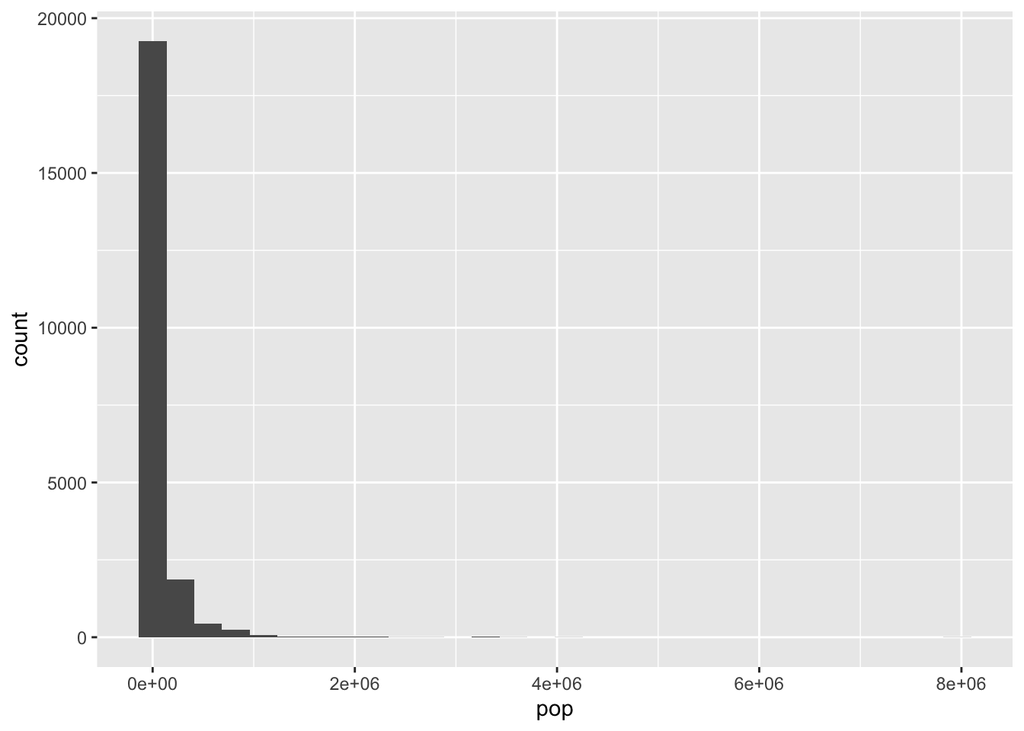

### Categorical variables

- Geographic area size (NCHSUR Codes, 2013)
- Winning political party at last presidential election (MIT Election Data and Science Lab, 2018)

#### Calculations & Results

| County Metropolitan Type | Sample proportion | 95-percent confidence - low | 95-percent confidence - high |
| --- | --- | --- | --- |
| Large central metro | 2 | 2 | 3 |
| Large fringe metro | 12 | 11 | 13 |

| Majority Party in 2020 | Sample proportion | 95-percent confidence - low | 95-percent confidence - high |
| --- | --- | --- | --- |
| REPUBLICAN | 82 | 82 | 83 |
| DEMOCRAT | 18 | 17 | 18 |

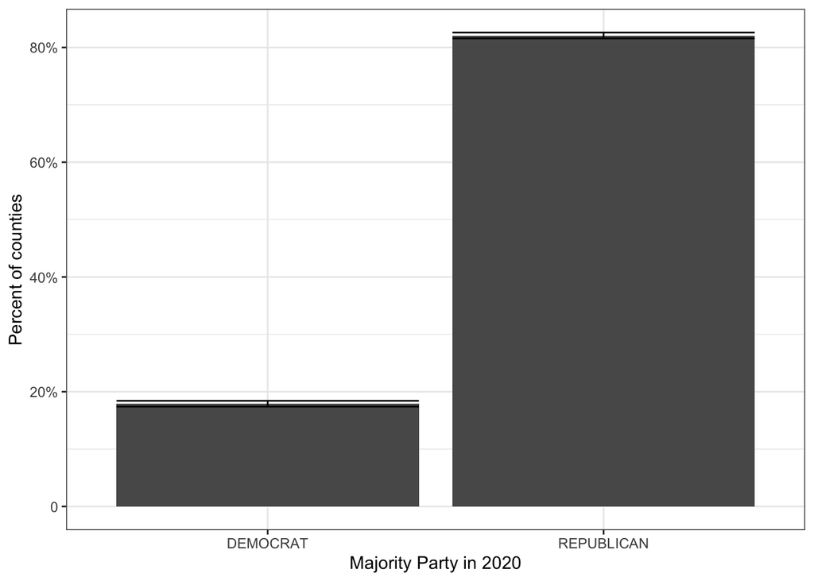

# Bivariate analysis

## Correlations & Regressions

The dependent variable is household income. The independent variables are the poverty ratio, gini coefficient, democratic party voting, and metropolitan type.

### Correlations for continuous variables

- Household Income & Poverty ratio
- Household Income & Gini Coefficient

```
##
##  Pearson's product-moment correlation
##
## data:  household_income_E and income_to_poverty_E
## t = 914.51, df = 21990, p-value < 2.2e-16
## alternative hypothesis: true correlation is not equal to 0
## 95 percent confidence interval:
##  0.9867640 0.9874413
## sample estimates:
##       cor
## 0.9871071
```

From this data comparison we can see that there is a strong linear correlation between household income and the income to poverty ratio. Although the measurement of income has the same input variables, “there is a tendency in household surveys for respondents to under report their income”. This evaluation become even more relevant because, “Median household income was $67,521 in 2020, a decrease of 2.9 percent from the 2019 median of $69,560 (Figure 1 and Table A-1). This is the first statistically significant decline in median household income since 2011”. Given the discrepancy in household reporting and the decrease in household income a correlation to the income to povery ratio should not be 1.

```
##
##  Pearson's product-moment correlation
##
## data:  household_income_E and gini_index_E
## t = 16.302, df = 21990, p-value < 2.2e-16
## alternative hypothesis: true correlation is not equal to 0
## 95 percent confidence interval:
##  0.09619711 0.12231475
## sample estimates:
##       cor
## 0.1092748
```

In this test we see a weak positive relationship between household income and the gini index.

### Regressions for continuous variables

- Household Income & Income to poverty ratio
- Household Income & Gini Index

```
##
## Call:
## lm(formula = household_income_E ~ income_to_poverty_E, data = data)
##
## Residuals:
##     Min      1Q  Median      3Q     Max
## -283939   -2752   -1707     722  402204
##
## Coefficients:
##                      Estimate Std. Error t value Pr(>|t|)
## (Intercept)         3.059e+03  1.230e+02   24.86   <2e-16 ***
## income_to_poverty_E 1.581e+00  1.728e-03  914.51   <2e-16 ***
## ---
## Signif. codes:  0 '***' 0.001 '**' 0.01 '*' 0.05 '.' 0.1 ' ' 1
##
## Residual standard error: 17340 on 21990 degrees of freedom
##   (2 observations deleted due to missingness)
## Multiple R-squared:  0.9744, Adjusted R-squared:  0.9744
## F-statistic: 8.363e+05 on 1 and 21990 DF,  p-value: < 2.2e-16
```

On average, the difference in the yearly household income we should expect for each one-year difference in the income to poverty ratio is 1.581. The p-value is 2e-16. The Multiple R-squared value indicates the percent of the variation in household income that can be explained by the variation in the income to poverty ratio. It’s very large, 97.44% of the variation in household income can be explained by differences in the income to poverty ratio. This makes sense because these two continuous variables pull from the same census questions. However, as mentioned before there is an expect misrepresentation in household income that occurs, leading the data to not completely overlap between the two variables.

```
##
## Call:
## lm(formula = household_income_E ~ gini_index_E, data = data)
##
## Residuals:
##     Min      1Q  Median      3Q     Max
## -120267  -33327  -21946   -5830 3261728
##
## Coefficients:
##              Estimate Std. Error t value Pr(>|t|)
## (Intercept)   -107564       8966   -12.0   <2e-16 ***
## gini_index_E   325132      19944    16.3   <2e-16 ***
## ---
## Signif. codes:  0 '***' 0.001 '**' 0.01 '*' 0.05 '.' 0.1 ' ' 1
##
## Residual standard error: 107700 on 21990 degrees of freedom
##   (2 observations deleted due to missingness)
## Multiple R-squared:  0.01194,    Adjusted R-squared:  0.0119
## F-statistic: 265.8 on 1 and 21990 DF,  p-value: < 2.2e-16
```

On average, the difference in the yearly household income we should expect for each one-year difference in the gini index is 325132 (county level, not individual household level). The p-value is 2e-16. The Multiple R-squared value indicates the percent of the variation in household income that can be explained by the variation in the gini index. It’s very small, 1.2% of the variation in household income can be explained by differences in the gini index. This makes sense because the gini index is a summary measure of income inequality that does not directly explain the household dollar amount. Rather the gini index gives an “idea” of the general income inequality.

### Regressions for categorical variables

- Household Income & Majority Vote
- Household Income & Type

```
##
## Call:
## lm(formula = household_income_E ~ majority_vote, data = data)
##
## Residuals:
##     Min      1Q  Median      3Q     Max
## -117632  -17470  -12337    1572 3198874
##
## Coefficients:
##                         Estimate Std. Error t value Pr(>|t|)
## (Intercept)               117921       1628   72.42   <2e-16 ***
## majority_voteRepublican   -97124       1797  -54.04   <2e-16 ***
## ---
## Signif. codes:  0 '***' 0.001 '**' 0.01 '*' 0.05 '.' 0.1 ' ' 1
##
## Residual standard error: 101900 on 21879 degrees of freedom
##   (113 observations deleted due to missingness)
## Multiple R-squared:  0.1178, Adjusted R-squared:  0.1177
## F-statistic:  2921 on 1 and 21879 DF,  p-value: < 2.2e-16
```

Based on the R-Squared value (12%), there seems to be little explanation of the observed variation based upon the model’s inputs of household income and percent of republican voting.

```
##
## Call:
## lm(formula = household_income_E ~ type, data = data)
##
## Residuals:
##     Min      1Q  Median      3Q     Max
## -431658  -10753   -1983    4331 2814539
##
## Coefficients:
##                        Estimate Std. Error t value Pr(>|t|)
## (Intercept)              502256       3907   128.6   <2e-16 ***
## typeLarge fringe metro  -425432       4205  -101.2   <2e-16 ***
## typeMedium metro        -439239       4166  -105.4   <2e-16 ***
## typeMicropolitan        -485568       4098  -118.5   <2e-16 ***
## typeNon-core            -496218       4004  -123.9   <2e-16 ***
## typeSmall metro         -470840       4236  -111.2   <2e-16 ***
## ---
## Signif. codes:  0 '***' 0.001 '**' 0.01 '*' 0.05 '.' 0.1 ' ' 1
##
## Residual standard error: 81760 on 21908 degrees of freedom
##   (80 observations deleted due to missingness)
## Multiple R-squared:  0.4322, Adjusted R-squared:  0.4321
## F-statistic:  3336 on 5 and 21908 DF,  p-value: < 2.2e-16
```

```r
t.test(household_income_E ~ majority_vote, data)
```

```
##
##  Welch Two Sample t-test
##
## data:  household_income_E by majority_vote
## t = 26.499, df = 3958.3, p-value < 2.2e-16
## alternative hypothesis: true difference in means between group Democrat and group Republican is not equal to 0
## 95 percent confidence interval:
##   89938.71 104310.24
## sample estimates:
##   mean in group Democrat mean in group Republican
##                117921.02                 20796.55
```

Based on the R-Squared value (43%), there seems to be somewhat of an explanation of the observed variation based upon the model’s inputs of household income and type of metropolitan area.

# Multivariate Regression

```
##
## Call:
## lm(formula = household_income_E ~ gini_index_E + income_to_poverty_E +
##     majority_vote + type, data = data)
##
## Residuals:
##     Min      1Q  Median      3Q     Max
## -253671   -3221    -204    2466  363122
##
## Coefficients:
##                           Estimate Std. Error t value Pr(>|t|)
## (Intercept)              2.078e+04  1.857e+03   11.19   <2e-16 ***
## gini_index_E             6.047e+04  3.232e+03   18.71   <2e-16 ***
## income_to_poverty_E      1.515e+00  2.121e-03  714.27   <2e-16 ***
## majority_voteRepublican -3.852e+03  3.184e+02  -12.10   <2e-16 ***
## typeLarge fringe metro  -3.912e+04  1.003e+03  -39.02   <2e-16 ***
## typeMedium metro        -3.712e+04  1.005e+03  -36.93   <2e-16 ***
## typeMicropolitan        -4.180e+04  1.028e+03  -40.65   <2e-16 ***
## typeNon-core            -4.308e+04  1.023e+03  -42.12   <2e-16 ***
## typeSmall metro         -3.940e+04  1.039e+03  -37.90   <2e-16 ***
## ---
## Signif. codes:  0 '***' 0.001 '**' 0.01 '*' 0.05 '.' 0.1 ' ' 1
##
## Residual standard error: 16290 on 21872 degrees of freedom
##   (113 observations deleted due to missingness)
## Multiple R-squared:  0.9775, Adjusted R-squared:  0.9775
## F-statistic: 1.186e+05 on 8 and 21872 DF,  p-value: < 2.2e-16
```

Multivariate Regression Analysis:

All of the values are significant at a 95% confidence interval

In terms of the effect of these variables on household income we found the following:

*Income to poverty ratio: increase 1.5 per capita household income

# Transformation

## Mean Centering

|  | Initial | Centered |
| --- | --- | --- |
| (Intercept) | 20782.60 *** (p = 0.00) | 80166.22 *** (p = 0.00) |
| gini_index_E | 60469.29 *** (p = 0.00) | 69794.57 *** (p = 0.00) |
| income_to_poverty_E | 1.52 *** (p = 0.00) | 1.52 *** (p = 0.00) |
| majority_voteRepublican | -3851.58 *** (p = 0.00) |  |
| typeLarge fringe metro | -39122.98 *** (p = 0.00) | -40308.69 *** (p = 0.00) |
| typeMedium metro | -37120.12 *** (p = 0.00) | -38931.46 *** (p = 0.00) |
| typeMicropolitan | -41800.34 *** (p = 0.00) | -43812.27 *** (p = 0.00) |
| typeNon-core | -43075.27 *** (p = 0.00) | -45162.84 *** (p = 0.00) |
| typeSmall metro | -39395.60 *** (p = 0.00) | -41224.66 *** (p = 0.00) |
| N | 21881 | 21914 |
| R2 | 0.98 | 0.98 |
| *** p < 0.001; ** p < 0.01; * p < 0.05. |  |  |

|  | Initial | Centered |
| --- | --- | --- |
| Constant | 20782.60 *** (p = 0.00) | 80166.22 *** (p = 0.00) |
| Gini Coefficient | 60469.29 *** (p = 0.00) | 69794.57 *** (p = 0.00) |
| Large fringe metro | -39122.98 *** (p = 0.00) | -40308.69 *** (p = 0.00) |
| Medium metro | -37120.12 *** (p = 0.00) | -38931.46 *** (p = 0.00) |
| Small metro | -39395.60 *** (p = 0.00) | -41224.66 *** (p = 0.00) |
| Micropolitan | -41800.34 *** (p = 0.00) | -43812.27 *** (p = 0.00) |
| Rural | -43075.27 *** (p = 0.00) | -45162.84 *** (p = 0.00) |
| N | 21881 | 21914 |
| R2 | 0.98 | 0.98 |
| *** p < 0.001; ** p < 0.01; * p < 0.05. |  |  |

# Interactions

In the output below we have a linear relationship estimated by the mean centering model. We can see that the relationship between the household income and gini coefficient is positive.

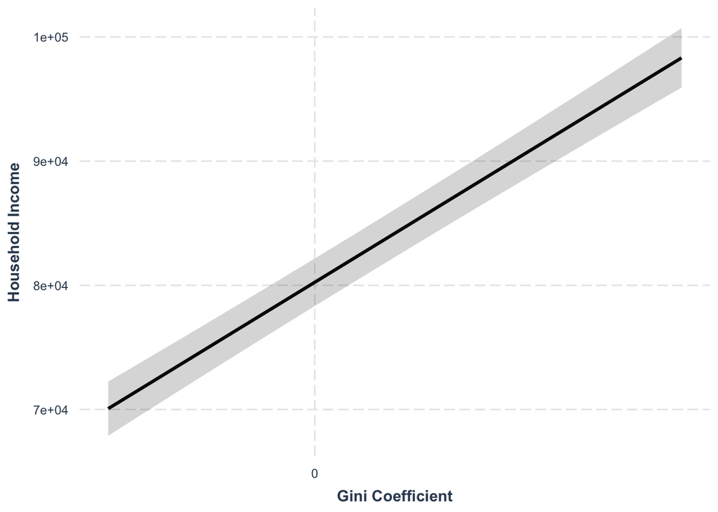

We wanted to see if the relationship between household income and the gini coefficient index changes depending on the type of county. In order to to test this we interacted the gini coefficient with the county type in the model below.

|  | Model 1 | Model 2 |
| --- | --- | --- |
| Constant | 80166.22 *** (p = 0.00) | 495874.41 *** (p = 0.00) |
| Gini Coefficient | 69794.57 *** (p = 0.00) | 183118.68 *** (p = 0.00) |
| Large fringe metro | -40308.69 *** (p = 0.00) | -415597.62 *** (p = 0.00) |
| Medium metro | -38931.46 *** (p = 0.00) | -433074.14 *** (p = 0.00) |
| Small metro | -41224.66 *** (p = 0.00) | -464832.03 *** (p = 0.00) |
| Micropolitan | -43812.27 *** (p = 0.00) | -480018.03 *** (p = 0.00) |
| Rural | -45162.84 *** (p = 0.00) | -489905.21 *** (p = 0.00) |
| N | 21914 | 21914 |
| R2 | 0.98 | 0.44 |
| *** p < 0.001; ** p < 0.01; * p < 0.05. |  |  |

# References

NCHSUR Codes, 2013.

United States Census Bureau, 2020.

American Community Survey, 2019.

MIT Election Data and Science Lab, 2018, “County Presidential Election Returns 2000-2020”, https://doi.org/10.7910/DVN/VOQCHQ, Harvard Dataverse, V9, UNF:6:qSwUYo7FKxI6vd/3Xev2Ng== [fileUNF]

Gelman, A., Kenworthy, L., & Su, Y. S. (2010). Income Inequality and Partisan Voting in the United States*. Social Science Quarterly, 91(5), 1203–1219. https://doi.org/10.1111/j.1540-6237.2010.00728.x

Verba, S. (2003). Would the Dream of Political Equality Turn out to Be a Nightmare? Perspectives on Politics, 1(4), 663–679. https://doi.org/10.1017/s1537592703000458

Census Subject Definitions (2021). https://www.census.gov/programs-surveys/cps/technical-documentation/subject-definitions.html#incomemeasurement

EMILY A. SHRIDER, MELISSA KOLLAR, FRANCES CHEN, AND JESSICA SEMEGA (2021) Income and Poverty in the United States: 2020. Current Population Reports, 2.